# DWEI5_Aula08_JS-TiposDeDados

Instituto Federal de São Paulo (IFSP)  
[Campus Bragança Paulista/SP](https://bra.ifsp.edu.br)  
**Análise e Desenvolvimento de Sistemas (ADS)**  
**5o. módulo**  
**Profa. Ana Paula Müller Giancoli**  
paulagiancoli@ifsp.edu.br

## AULA 08 - JAVASCRIPT - TIPOS DE DADOS

### Agenda

- Conceitos básicos
- Comentário
- Tipos de Dado
- Variáveis e Constantes
- Escopo de Variável
- Sintaxe
- Exibindo no console.log()
- Primeiro programa
- Importante
- Literais
- Escape Sequence
- Entrada de dados
- Atribuição
- Operadores aritméticos
- Operadores relacionais
- Operadores lógicos
- Operadores de Atribuição
- Outros
- Inserindo um script no index.html
- Perguntas

### 1. Conceitos Básicos

### 1.1. Como surgiu o javascript

- Surgiu como **Mocha**.
- Em 1995, tornou-se **LiveScript**, sendo lançada em conjunto com o navegador da época, Netscape.
- No mesmo ano, em dezembro, seu nome foi alterado para JavaScript.
- Para conhecimento [Javascript](https://pt.wikipedia.org/wiki/JavaScript).
- Para aprofundamento, consulte o livro [Eloquent Javascript - 3a. Edição](https://eloquentjavascript.net/).

### 1.2. Javascript foi criada por

- Criada por **Brendan Eich** (nascido em 1961, nos EUA).
- Brendan Eich ficou conhecido pelo seu trabalho na Netscape e Mozilla.
- Foi ele quem ajudou a fundar a Mozilla.org em 1998.
- Para conhecimento [Brendan Eich](https://pt.wikipedia.org/wiki/Brendan_Eich).

### 1.3. O que é Javascript

- **Javascript** ou simplesmente, **JS**.
- É uma linguagem de script multiplataforma e orientada a objetos.
- É uma linguagem pequena e leve.
- É **case-sensitive** e utiliza um conjunto de caracteres [UNICODE](https://unicode-table.com/pt/).
- Originalmente,foi desenvolvida para rodar no lado do cliente, isto é, a interpretação e o funcionamento dependem de funcionalidades hospedadas no navegador do usuário.
- É interpretada e baseada em objetos com funções de primeira classe, mais conhecida como a linguagem de script para páginas Web.
- Não é útil como uma linguagem independente mas foi projetada para ser facilmente incorporada a outros produtos e aplicações, como navegadores web.
- Para conhecimento [Javascript](https://pt.wikipedia.org/wiki/JavaScript).

### 1.4. Evolução do Javascript

- Para que a linguagem evoluísse com determinados padrões e normativas, os criadores se associaram ao ECMA, em 1996.
- ECMA = European Computer Manufactures Association.
- O nome Javascript já havia sido patenteado pela SUN Microsystems (atual Oracle).
- **Novo nome foi necessário: junção das palavras ECMA e Javascript —> ECMAScript**.
  - Em **2017**: ECMAScript 2017, 8a. edição (ES8), lançado em junho de 2017.
  - Em **2018**: ECMAScript 2018, 9a. edição (ES9), lançado em junho de 2018.
  - Em **2019**: ECMAScript 2019, 10a. edição (ES10), lançado em junho de 2019.
  - Em **2020**: ECMAScript [2020](http://www.ecma-international.org/publications/standards/Ecma-262.htm), 11a. edição (ES11), lançado em junho de 2020.
  - Em **2021**: ECMASCript [2021](https://tc39.github.io/ecma262/) já está em desenvolvimento, e será lançado em 2021.

#### No VSCode, instalar Live Server.

- Utilizaremos como servidor para exibir nossas aplicações.

### 2. Comentários

### 2.1. Comentários de linha

- Um **comentário** em um programa de computador é um texto destinado apenas ao leitor humano.
- É completamente ignorado pelo interpretador.
- Utilizamos o **símbolo //**, no início da linha para indicar um comentário, assim, o resto da linha é ignorado.

### 2.2. Comentários de blocos

- Comentários em diversas linhas, poderemos utilizar a barra de divisão, seguida de um asterisco no início do comentário, e ao finalizar, inserir, mais um asterisco e uma barra de divisão.
- Utilizamos o **símbolo /***, no início da primeira linha para indicar um comentário e no final do bloco,*/.

### 3. Tipos de Dados - Valor

- Para aprofundamento, consulte [Javascript.info](https://javascript.info/).
- Um **valor** pode ser qualquer informação, seja: **uma letra, um número, um vídeo, uma música** que será manipulado pelo programa seguindo as instruções passadas.
- *Os valores são classificados em diferentes tipos de dados*.
- Para identificarmos o *tipo de dado* de um determinado valor, utilizamos o seguinte comando no **console do navegador (F12)**.
- **Tipos de valores**:
  - **number**: números inteiros, flutuantes.
  - **string**: conjunto de caracteres (strings).
  - **boolean**: armazenam os valores true, false.
  - **null**: não possui valores. Null não é uma "referência a um objeto inexistente" ou um "ponteiro nulo", como em outras linguagens.
  - **undefined**: variável declarada sem associação de valor, logo será undefined. Valor não atribuído.
  - **symbol**: um valor único que não é igual a nenhum outro valor.
  - **bigInt**: o tipo foi adicionado recentemente ao idioma para representar números inteiros de comprimento arbitrário.

#### Para identificarmos qual é o tipo do valor, utilizamos a função typeof.

```
typeof "Ana Paula"
"string"


typeof 70
"number"


typeof 1.88
"number"


typeof "a"
"string"


typeof true
"boolean"

// Não é muito utilizado.
typeof undefined
"undefined"

// Utilizado para iniciar e redefinir um valor posteriormente
let corSelecionada = null;
// Posteriormente a cor é modificada
typeof(null)
"object"

typeof Symbol("id");
"symbol"

typeof(alert)
"function"
```

### 3.1. String

- Existem dois tipos de String:
  - **Tipo primitivo**.
    - Em JavaScript, existem 3 tipos de citações:
      - Aspas duplas: "Ana Paula".
      - Aspas simples: 'Ana Paula'.
      - Crases (backticks):

        ```
        `Ana Paula`
        ```

    - Não há diferença em utilizar aspas simples ou duplas, é a praticamente a mesma coisa.
    - Porém, as crases (backticks) possuem uma "funcionalidade estendida", conhecida como **template string**. Mantém os espaços e quebras definidos.
      - Permitem incorporar variáveis e expressões em uma string, envolvendo-as **$ { … }**:

    ```
    const nome = "Ana Paula";
    alert(`Bom dia, ${nome}`);

    alert(`Multiplicação de 10 * 3 = ${10 * 3}`);

    typeof nome // saída: "string"
    ```

  - **Tipo objeto**.

    ```
    const nome1 = new String("Ana Paula");

    typeof nome1 // saída: "object"
    ```

### 3.1.1. Propriedades, Métodos

- Para aprofundar, consulte [MDN Web Docs](https://developer.mozilla.org/pt-BR/docs/Web/JavaScript/Reference/Global_Objects/String).
- **Pesquisando um valor em uma string**:
  - Utiliza-se o **método includes(valor)**.
  - Retorna **true** ou **false**, conforme localiza ou não a string.

```
const nome = new String("Ana Paula");
nome.length;   // identifica o tamanho da variável. saída: 9
nome[1];       // saída: n
nome.includes("Paula");


const nome1 = "Ana Paula";
nome1.length;   // identifica o tamanho da variável. saída: 9
nome1[1];       // saída: n
nome1.includes("Giancoli");
```

- **Saída**:

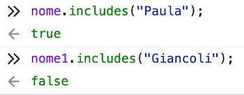

```
const nome = new String("Ana Paula");
const nome1 = "Ana Paula";
nome.startsWith("Ana");
nome.endsWith("Ana");
nome1.startsWith("Ana");
nome1.endsWith("Ana");
```

- **Saída**:

[figure not shown]

- **Identificando o índice de uma string**:
  - Utiliza-se o **método indexOf(valor)** para verificar o índice deste valor.
  - Retorna o índice.
- **Substituindo um valor em uma string**:
  - Utiliza-se o **método replace(valor, comvalor)** para substituir o primeiro valor pelo segundo.
- **Removendo espaços de uma string no início ou final**:
  - Utiliza-se o **método trim(valor)** para excluir os espaços.

```
const cidade = " Bragança Paulista  ";
cidade.trim();     // Saída: "Bragança Paulista"
```

- **Saída**:

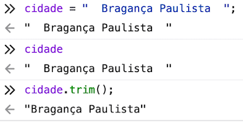

- **Separando a string**:
  - Utiliza-se o **método split(valor)** para separar a string por meio do valor indicado. Neste exemplo, foi utilizado o asterisco como separador.
  - Retorna um array com as strings separadas.
- **Saída**:

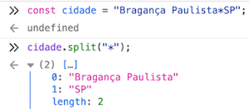

- **Saída**:
- Outro exemplo:

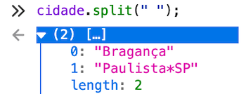

- **Saída**:
- Outro exemplo:

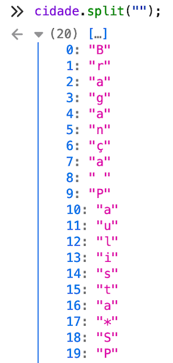

### 3.2. Date

- Manipulando datas.
- Consulte [MDN Web Docs](https://developer.mozilla.org/pt-BR/docs/Web/JavaScript/Reference/Global_Objects/Date).

```
const data1 = new Date();  // exibe a data atual
const data2 = new Date('March 23 2021 14:50');
const data3 = new Date(2021,02,23,14,50);  // os meses começam no 00, 01, 02, 03 ... onde 00 é janeiro.
```

- **Saída**:

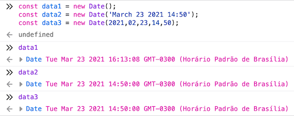

- **Alterando valores**:

```
const data4 = new Date(2021,02,23,14,50);  // os meses começam no 00, 01, 02, 03 ... onde 00 é janeiro.
data4.setFullYear(2020);  // alterando o ano da variável data3
data4.toDateString();   // convertendo data para string
date4.toISOString();    // convertendo para o formato usando em banco de dados
date4.toTimeString();   // convertendo formato horário de brasília
```

- **Saída**:

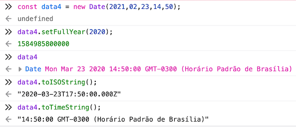

### 4. Variáveis e Constantes

- Para aprofundamento, consulte [Javascript.info](https://javascript.info/variables).
- É um espaço de memória que reservamos para armazenar valores temporários que estão sendo processados ou manipulados.
- Seu valor poderá ser alterado a qualquer momento.
- O nome da variável, referência, é como iremos nos referir a um determinado espaço de memória.

### 4.1. Regras

- As variáveis são como nomes simbólicos para os valores em sua aplicação. O nome das variáveis, chamados de identificadores, obedecem determinadas regras.
- Os identificadores podem começar com underline, caracteres e cifrão, seguidos por números. Porém, nunca começar com números.
- Não é permitido o nome de variáveis utilizando as palavras reservadas.
- São case sensitive.
- Para a definição de nomes de variáveis utilizaremos o **camelCase**.
  - [Significado](https://pt.wikipedia.org/wiki/CamelCase): "CamelCase é a denominação em inglês para a prática de escrever as palavras compostas ou frases, onde cada palavra é iniciada com maiúsculas e unidas sem espaços. É um padrão largamente utilizado em diversas linguagens de programação, como Java, C#, Ruby, PHP e Python, principalmente nas definições de classes e objetos."
- Existem 3 tipos de declarações em Javascript:
  - var: declara uma variável e opcionalmente, um valor. (Praticamente não é mais usado!)
  - let: declara uma variável local de escopo do bloco, opcionalmente, inicializando-a com um valor.
  - const: declara uma constante apenas de leitura. É imutável.
- As declarações podem ser:
  - Recomendável o uso de uma linha por variável para tornar o código legível.

```
/* não recomendável */
let nome = "Ana", sobrenome = "Giancoli";

/* ou */
let nome = "Ana",
    sobrenome = "Giancoli";

/* ou */
let nome = "Ana";
let sobrenome = "Giancoli";
```

### 4.1.1. Possíveis erros de declaração de variáveis

- Variável declarada usando a declaração **var ou let** sem atribuição de valor —> **undefined**.
- Tentativa de acessar uma **variável não declarada** —> **ReferenceError**.
- Tentativa de **somar um texto** —> **NaN**
- Poderá usar **undefined** para determinar se uma variável tem um valor. Como por exemplo:

  ```
  if (input === undefined) {
  ...
  }
  ```

### 4.2. Constantes

- Utilize a palavra **const antes do nome da constante**.
- *Não pode alterar seu valor por meio de atribuição, ou ser declarada novamente*.
- Existe uma prática generalizada de usar constantes como aliases para valores difíceis de lembrar que são conhecidos antes da execução. Essas constantes são nomeadas usando letras maiúsculas e sublinhados.
- **Deve ser inicializada com um valor**. Como por exemplo:

  ```
  const x = 10;
  const COLOR_RED = #f00;
  ```

### 5. Escopo de variável

- Quando você declara uma **variável fora de qualquer função**, é **chamada de variável global**, porque está disponível para qualquer outro código no documento atual.
- Quando você declara uma **variável dentro de uma função**, é **chamada de variável local**, pois está disponível somente dentro dessa função.
- **Javascript antes do ECMAScript 6** *não possuía escopo de declaração de bloco* pelo contrário, uma variável declarada dentro de um bloco de uma função é uma variável local (ou contexto global) do bloco que está inserido a função.
- **Exemplos**:

```
if (true) {
    var x = 5;
}
console.log(x);


if (true) {
    let y = 10;
}
console.log(y);
```

**Saída:**

**let y = 10;**

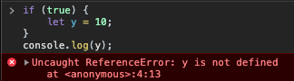

### 6. Sintaxe

- Em Javascript, a **indentação também é importante para facilitar a leitura do código**.
- **Cada linha é finalizada com um ponto e vírgula ;**.
- Os **blocos de instruções** são **delimitados pela chaves { ... }**.
- Os blocos são uma ou mais instruções que devem ser executadas uma após a outra, de cima para baixo da esquerda para a direita.

### 7. Exibindo no console

- Por meio do uso de **console.log(conteúdo)** é possível visualizar o resultado do comando no navegador.
- Onde texto poderá ser variável, string, objeto, erros etc.
- Podemos exibir os dados no console, utilizando a saída formatada.

| String de substituição | Descrição |
| --- | --- |
| %o | Exibe um link para o objeto javascript. Ao selecionar o link, abre um inspetor. |
| %d ou %i | Exibe um número inteiro. A formatação ainda não possui suporte. |
| %s | Exibe um string. |
| %f | Exibe um número flutuante. A formatação ainda não possui suporte. |

**Exemplos**

```
/* Exemplo1 */
let nome = "Ana";
let ano = 2008;
console.log("A profa. %s iniciou no IFSP no ano de %d.", nome, ano);

/* Exemplo2 */
let nome = "Ana";
let ano = 2008;
aluguel = 100.94;
console.log("A profa. %s iniciou no IFSP no ano de %d.", nome, ano);
console.log("O aluguel mensal do estacionamento custa em torno de %f.", aluguel);

/* Exemplo3 */
let user = new Object();
user.first = "Ana";
user.last = "Giancoli";
user.age = 10.28;
console.log("Olá, %s %s! Seja bem vinda!", user.first, user.last);
console.log("%s tem %i anos!", user.first, user.age);
console.log("%s tem %f anos!", user.first, user.age);

/* Exemplo4 */
let url = "http://bra.ifsp.edu.br";
let nome = "IFSP_BRA";
console.log("O site do %s é %o .", nome, url);
```

**Saída:**

Exemplo 1

Exemplo 2

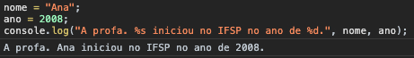

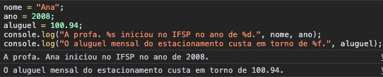

**Exemplo 3**

**Exemplo 4**

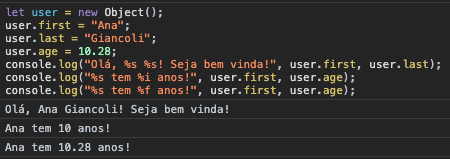

[output not shown]

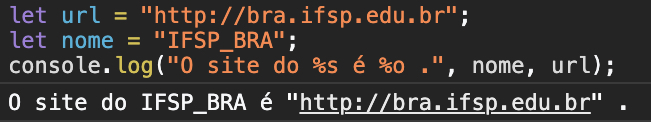

[output not shown]

### 8. Primeiro Programa

- Para exibir mensagens no console, utilize a sintaxe indicada abaixo.

```
console.log("Hello World!!");
```

### 9. Importante

- Para maiores informações sobre o uso do console, consulte [Basques, Kayce - Console API Reference](https://developers.google.com/web/tools/chrome-devtools/console/api?utm_source=dcc&utm_medium=redirect&utm_campaign=2016q3).
- Javascript por ser uma linguagem dinamicamente tipada, não precisamos especificar o tipo de dado.
- **Os tipos de dados serão convertidos conforme a execução**.

#### Expressões envolvendo strings, valores numéricos e outros

- Em **expressões envolvendo valores numéricos e strings** com o **operador +**, a linguagem JavaScript **converte valores numéricos para strings**.

```
x = "A resposta é "+ 42;
y = 42 + " é a resposta.";
console.log(x);
console.log(y);
```

- Nas **declarações envolvendo outras operações**, *não é feita a conversão*.

```
k = "88"- 30;
j = 56 * "2";
console.log(k);
console.log(j);
```

### 9.1. Conversão de Tipos

### 9.1.1. Number, String, Boolean

- De acordo com [Javascript.info] as três conversões de tipo mais usadas são string, number e boolean.

#### Conversão para String:

- Ocorre quando produzimos algo. A conversão para string geralmente é óbvia para valores primitivos.
  - **Sintaxe**: String(valor).

#### Conversão para Number:

- Ocorre em operações matemáticas.
  - **Sintaxe**: Number(valor).
  - A conversão segue as regras:

| Valor | É convertido em |
| --- | --- |
| undefined | NaN |
| null | 0 |
| true / false | 1 / 0 |
| string | A string é lida "como está", os espaços em branco de ambos os lados são ignorados. Uma cadeia vazia se torna 0. Um erro dá NaN. |

- **Observações**:
  - **Number(object)** tenta converter a string inteira em um número (que também pode ser um float).
  - Quando usamos **parseInt(valor)** ou **parseFloat(valor)**, é feito uma análise do primeiro dígito e retorna o valor que foi analisado.

```
Number('123num');
NaN

parseInt('123num');
123
```

#### Conversão para Boolean:

- Ocorre em operações lógicas.
  - **Sintaxe**: Boolean(valor).
  - Segue as regras:

[output not shown]

- **Observações**:
  - A maioria dessas regras é fácil de entender e memorizar. As exceções notáveis em que as pessoas geralmente cometem erros são:
  - undefined é NaN como um número, não 0.
  - "0" e strings apenas de espaço como " " são verdadeiras como booleanas.

### 9.1.2. Parse

- A linguagem Javascript ainda aceita a conversão utilizando parse, porém conforme já explicado anteriormente, ao utilizar parse, é feita uma análise somente no primeiro dígito e não no conteúdo inteiro.
- **Inteiro para Float**:
  - Para convertermos um tipo de dado **inteiro para float**, utilizamos **parseFloat(valor)**.
- **Float para Inteiro**:
  - Para convertermos um tipo de dado **float para inteiro**, utilizamos **parseInt(valor)**. Perdemos precisão.
- **String para Inteiro**:
  - Para convertermos um tipo de dado **string para inteiro**, utilizamos **parseInt(valor)**.

### 9.2 Alguns métodos de string

#### Métodos de String

- Podemos **chamar** qualquer um dos **métodos do objeto string** em uma **string literal**.
- JavaScript **automaticamente converte a string literal** para **um objeto string temporário**, chama o método, e em seguida, descarta o objeto string temporário.

```
console.log("Ana Paula".length);
console.log("Ana Paula".toUpperCase() );
console.log("Ana Paula".toLowerCase() );
```

### 10. Literais

- Usamos os literais para representar valores em Javascript.
- Estes são valores fixados, são valores não variáveis, que você literalmente insere em seu script.
- São eles:  
  #### Array literal
- É uma lista de zero ou mais expressões, onde cada uma delas **representam um elemento do array**, inseridas entre **colchetes** "[...]".
  - Quando você cria um array usando um array literal, ele é inicializado com os valores especificados como seus elementos, e seu comprimento é definido com o número de elementos especificados.
- Para acessar um elemento do array, utiliza-se índices a partir de zero.
- Para saber o tamanho, utilize **length**. Exemplo: capmix.length

```
let cap = ["Cap01", "Cap02", "Cap03", "Cap04", "Cap05"];
let capmix = ["Cap01", 10, 18.95, "Cap04", 10*7];
console.log(cap);
console.log(capmix);
```

**Saída:**

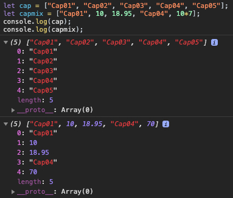

### 10.1. Manipulando Arrays

- Adicionando elementos no Array.

```
const numint = [1, 5, 7, 14, 1678, 90];
    console.log(numint);  // Saída: Array(6) [ 1, 5, 7, 14, 1678, 90 ]
```

**Saída:**

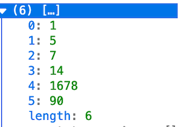

#### Utiliza-se o *método unshift(valor)* para adicionar valores no início do Array.

```
numint.unshift(10, 20, 50);
console.log(numint);
```

**Saída:**

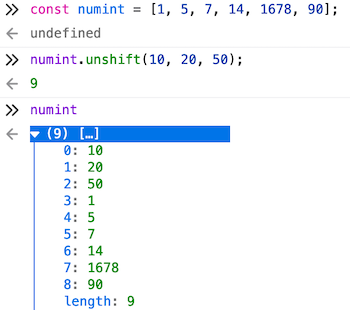

#### Utiliza-se o *método splice(indice, delete, valor)* para adicionar valores no meio do Array.

```
numint.splice(6, 0, 1000); // onde 0, estou indicando que não foi remover elemento. Inserir o valor 1000, a partir do índice 6 - inclusive.
console.log(numint);
```

**Saída:**

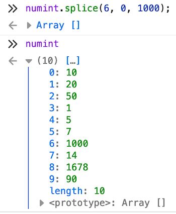

#### Utiliza-se o *método push(valor)* para adicionar valores no final do Array.

```
numint.push(6754);
console.log(numint);
```

**Saída:**

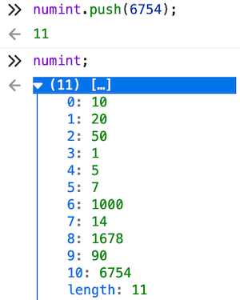

#### Utiliza-se o *método indexOf(valor)* para indentificar o índice de um elemento no Array. Similar a String.

- Retorna o **índice** quando encontra.
- Retorna **-1**, quando não encontra.

```
const num = [ 1, 3, 4, 6 ];
x = num.indexOf(4);
y = num.indexOf(12);
```

**Saída:**

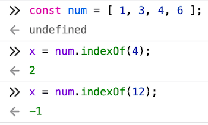

#### Utiliza-se o *método lastIndexOf(valor)* para indentificar o último índice de um elemento no Array.

```
const num1 = [ 1, 3, 4, 6, 5, 12, 4 ];
x = num1.lastIndexOf(4);
y = num1.lastIndexOf(12);
```

**Saída:**

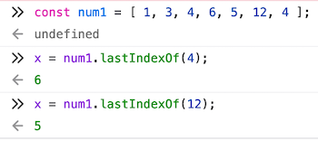

#### Pesquisando um valor em um Array

- Utiliza-se o **método includes(valor)**.
- Retorna **true** ou **false**, conforme localiza ou não o valor. Similar a string.

#### Localizando o primeiro objeto de um Array de objetos.

- Utiliza-se o **método find()**.

```
const nomes = [
    {id: 1, nome: "Ana"},
    {id: 2, nome: "Paula"},
    {id: 3, nome: "Ana"}
];

console.log(nomes.find(function(nome){
    return nome.nome === 'Ana'
}));
```

#### Removendo elementos dos Arrays.

```
const nomes = ["Ana", "Paula", "Müller", "Giancoli", "Bragança"];
console.log(nomes);
```

- Utiliza-se o **método pop( )** para remover do final.

```
// Remove do Final
x = nomes.pop();
console.log('Removido último: '+ x);
console.log(nomes);
```

- Utiliza-se o **método shift( )** para remover do início.

```
// Remove do início
y = nomes.shift();
console.log('Removido primeiro: ' + y);
console.log(nomes);
```

- Utiliza-se o **método splice(indice, quantosRemover)** para remover do meio do array.

```
// Remove de um indice especifico a quantidade informada.
z = nomes.splice(2, 1);
console.log('Removido do meio: '+ z);
console.log(nomes);
```

**Saída:**

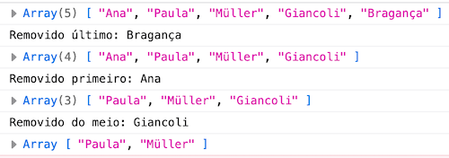

#### Utiliza-se a *atribuição de array vazio* para esvaziá-lo.

- Caso existam diversas referências a este array, elas não serão excluídas.
- Lembrando que, se definido como **const**, não será possível executar esta operação. Logo, o array precisa ser declarado com **let**.

```
// Apagando com a atribuição
let teste = [ 'a', 'b', 'c', 'd'];
console.log("Teste: " + teste)

teste1 = teste;
teste = [];

console.log("Teste: " + teste)
console.log("Teste1: " + teste1)
```

**Saída:**

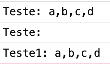

#### Utiliza-se a *.length = 0* para esvaziá-lo.

```
// Apagando todos os arrays e suas referências
let teste = [ 'a', 'b', 'c', 'd'];
console.log("Teste: " + teste)

teste1 = teste;

console.log("Teste: " + teste)
console.log("Teste1: " + teste1)

teste.length = 0;

console.log("Teste: " + teste)
console.log("Teste1: " + teste1)
```

**Saída:**

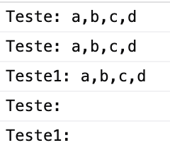

#### Utiliza-se a *método splice(0, array.length)* para esvaziá-lo.

```
// Apagando todos os arrays e suas referências
let teste = [ 'a', 'b', 'c', 'd'];
console.log("Teste: " + teste)

teste1 = teste;

console.log("Teste: " + teste)
console.log("Teste1: " + teste1)

teste.splice(0, teste.length);

console.log("Teste: " + teste)
console.log("Teste1: " + teste1)
```

**Saída:**

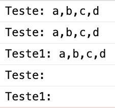

#### Concatenando Arrays

- Utiliza-se o **método array.concate(array)**.

```
let inicio = [ 'a', 'b', 'c', 'd'];
let fim = [ 'e', 'f', 'g', 'h'];

let uniao = inicio.concat(fim);

console.log("Início: " + inicio);
console.log("Fim: " + fim);
console.log("União: " + uniao);
```

**Saída:**

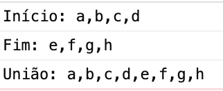

#### Fatiando Arrays

- Utiliza-se o **método slice(indiceInicial, indiceFinal)**. O índiceFinal é índice - 1.

```
let separacao = uniao.slice(2,3);
console.log("Separação: " + separacao);
```

- Utiliza-se o **método slice(indiceInicial)**.

```
let separacao = uniao.slice(2);
console.log("Separação: " + separacao);
```

**Saída:**

[figure not shown]

- Utiliza-se o **método slice( )** para selecionar todos os valores.

```
let separacao = uniao.slice( );
```

#### Clonando por meio do uso da Sintaxe Spread

- Efetuando a cópia por meio da sintaxe spread {...}.

```
let inicio = [ 'a', 'b', 'c', 'd'];
let fim = [ 'e', 'f', 'g', 'h'];

let uniao = [...inicio, '***', ...fim]

console.log("Início: " + inicio);
console.log("Fim: " + fim);
console.log("União: " + uniao);
```

**Saída:**

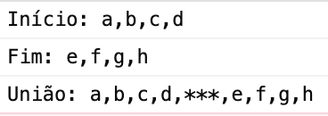

#### Objeto Literal

- É uma lista de zero ou mais **pares de nomes de propriedades e valores (key value par)** associados de um objeto, colocado entre **chaves** "{...}".

```
let tb = {
    nome: "Ana",
    sobrenome: "Giancoli",
    idade: 10,
    tipo: true,
    cidade: function cidade(){}
};
console.log(tb);
```

**Saída:**

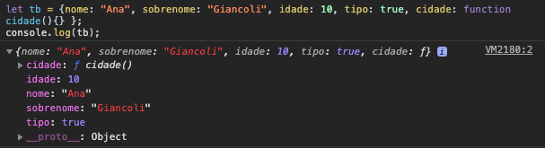

#### Exemplo: criando dois objetos

```
//Objetos bio e graduacao .
    let bio = {
        nome: "Ana",
        idade: 30,
        cidade: " Braganca ",
        estado: "SP"
    };
    let graduacao = {
        grad1 : "UFJF" ,
        grad2 : "CESJF" };
```

**Saída:**

[figure not shown]

#### Adicionando ou excluindo atributos, métodos aos objetos já criados

```
const carro = {
    marca : 'Ford',
    modelo : 'Focus',
}

carro.cor = 'prata';
carro.ligar = function() {
    console.log("Ligando carro ...");
}

console.log(carro);

delete carro.cor;
console.log(carro);
```

**Saída:**

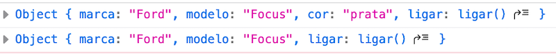

#### Clonando um objeto utilizando o método assign( ) de Object

```
const novoObjeto = Object.assign({}, carro)
console.log(novoObjeto);
```

#### Clonando um objeto utilizando o método assign( ) de Object adicionando novos atributos

```
const novoObjeto1 = Object.assign({
    cor: 'azul',
    brilho: false,
}, carro)
console.log(novoObjeto1);
```

#### Clonando por meio do uso da Sintaxe Spread

- Efetuando a cópia por meio da sintaxe spread {...}.

```
const objeto2 = {...novoObjeto1};
console.log(objeto2);
```

### 10.1. Exercício

- Elabore um programa que solicite o nome completo, o endereço completo e exiba estas informações no console. Utilize objeto e funções.

```
const nome = prompt("Informe seu nome completo: ")
let endereco = {
    logradouro : prompt("Indique o nome da rua: "),
    numero : prompt("Indique o número: "),
    bairro : prompt("Indique o bairro: "),
    cidade : prompt("Indique cidade: "),
}


function exibir(nome, endereco) {
    console.log(nome);
    for (let chave in endereco)
        console.log(chave, endereco[chave]);
}

exibir(nome, endereco);
```